# Risk Factor Analysis

## Outcome Variable

**Outcome Variable:** stunted

## Predictor Variables

**Intervention Variable:** mhtcm

**Adjustment Set:**

unadjusted

## Stratifying Variables

The analysis was stratified on these variable(s):

- agecat
- studyid
- country

## Data Summary

| agecat | studyid | country | mhtcm | stunted | n_cell | n |
| --- | --- | --- | --- | --- | --- | --- |
| Birth | COHORTS | GUATEMALA | >=155 cm | 0 | 104 | 840 |
| Birth | COHORTS | GUATEMALA | >=155 cm | 1 | 6 | 840 |
| Birth | COHORTS | GUATEMALA | <151 cm | 0 | 513 | 840 |
| Birth | COHORTS | GUATEMALA | <151 cm | 1 | 32 | 840 |
| Birth | COHORTS | GUATEMALA | [151-155) cm | 0 | 174 | 840 |
| Birth | COHORTS | GUATEMALA | [151-155) cm | 1 | 11 | 840 |
| Birth | COHORTS | INDIA | >=155 cm | 0 | 497 | 1774 |
| Birth | COHORTS | INDIA | >=155 cm | 1 | 33 | 1774 |
| Birth | COHORTS | INDIA | <151 cm | 0 | 657 | 1774 |
| Birth | COHORTS | INDIA | <151 cm | 1 | 106 | 1774 |
| Birth | COHORTS | INDIA | [151-155) cm | 0 | 436 | 1774 |
| Birth | COHORTS | INDIA | [151-155) cm | 1 | 45 | 1774 |
| Birth | COHORTS | PHILIPPINES | >=155 cm | 0 | 614 | 3050 |
| Birth | COHORTS | PHILIPPINES | >=155 cm | 1 | 16 | 3050 |
| Birth | COHORTS | PHILIPPINES | <151 cm | 0 | 1413 | 3050 |
| Birth | COHORTS | PHILIPPINES | <151 cm | 1 | 132 | 3050 |
| Birth | COHORTS | PHILIPPINES | [151-155) cm | 0 | 836 | 3050 |
| Birth | COHORTS | PHILIPPINES | [151-155) cm | 1 | 39 | 3050 |
| Birth | Keneba | GAMBIA | >=155 cm | 0 | 1130 | 1431 |
| Birth | Keneba | GAMBIA | >=155 cm | 1 | 57 | 1431 |
| Birth | Keneba | GAMBIA | <151 cm | 0 | 46 | 1431 |
| Birth | Keneba | GAMBIA | <151 cm | 1 | 5 | 1431 |
| Birth | Keneba | GAMBIA | [151-155) cm | 0 | 182 | 1431 |
| Birth | Keneba | GAMBIA | [151-155) cm | 1 | 11 | 1431 |
| Birth | MAL-ED | BANGLADESH | >=155 cm | 0 | 19 | 222 |
| Birth | MAL-ED | BANGLADESH | >=155 cm | 1 | 3 | 222 |
| Birth | MAL-ED | BANGLADESH | <151 cm | 0 | 115 | 222 |
| Birth | MAL-ED | BANGLADESH | <151 cm | 1 | 30 | 222 |
| Birth | MAL-ED | BANGLADESH | [151-155) cm | 0 | 48 | 222 |
| Birth | MAL-ED | BANGLADESH | [151-155) cm | 1 | 7 | 222 |

[output cut: 306 more lines]

The following strata were considered:

- agecat: 24 months, studyid: COHORTS, country: GUATEMALA
- agecat: 24 months, studyid: COHORTS, country: INDIA
- agecat: 24 months, studyid: COHORTS, country: PHILIPPINES
- agecat: 24 months, studyid: Keneba, country: GAMBIA
- agecat: 24 months, studyid: LCNI-5, country: MALAWI
- agecat: 24 months, studyid: MAL-ED, country: BANGLADESH
- agecat: 24 months, studyid: MAL-ED, country: BRAZIL
- agecat: 24 months, studyid: MAL-ED, country: INDIA
- agecat: 24 months, studyid: MAL-ED, country: NEPAL
- agecat: 24 months, studyid: MAL-ED, country: PERU
- agecat: 24 months, studyid: MAL-ED, country: SOUTH AFRICA
- agecat: 24 months, studyid: MAL-ED, country: TANZANIA, UNITED REPUBLIC OF
- agecat: 24 months, studyid: NIH-Birth, country: BANGLADESH
- agecat: 24 months, studyid: NIH-Crypto, country: BANGLADESH
- agecat: 24 months, studyid: PROBIT, country: BELARUS
- agecat: 24 months, studyid: PROVIDE, country: BANGLADESH
- agecat: 24 months, studyid: TanzaniaChild2, country: TANZANIA, UNITED REPUBLIC OF
- agecat: 24 months, studyid: ZVITAMBO, country: ZIMBABWE
- agecat: 6 months, studyid: COHORTS, country: GUATEMALA
- agecat: 6 months, studyid: COHORTS, country: INDIA
- agecat: 6 months, studyid: COHORTS, country: PHILIPPINES
- agecat: 6 months, studyid: Guatemala BSC, country: GUATEMALA
- agecat: 6 months, studyid: Keneba, country: GAMBIA
- agecat: 6 months, studyid: LCNI-5, country: MALAWI
- agecat: 6 months, studyid: MAL-ED, country: BANGLADESH
- agecat: 6 months, studyid: MAL-ED, country: BRAZIL
- agecat: 6 months, studyid: MAL-ED, country: INDIA
- agecat: 6 months, studyid: MAL-ED, country: NEPAL
- agecat: 6 months, studyid: MAL-ED, country: PERU
- agecat: 6 months, studyid: MAL-ED, country: SOUTH AFRICA
- agecat: 6 months, studyid: MAL-ED, country: TANZANIA, UNITED REPUBLIC OF
- agecat: 6 months, studyid: NIH-Birth, country: BANGLADESH
- agecat: 6 months, studyid: NIH-Crypto, country: BANGLADESH
- agecat: 6 months, studyid: PROBIT, country: BELARUS
- agecat: 6 months, studyid: PROVIDE, country: BANGLADESH
- agecat: 6 months, studyid: SAS-CompFeed, country: INDIA
- agecat: 6 months, studyid: SAS-FoodSuppl, country: INDIA
- agecat: 6 months, studyid: TanzaniaChild2, country: TANZANIA, UNITED REPUBLIC OF
- agecat: 6 months, studyid: ZVITAMBO, country: ZIMBABWE
- agecat: Birth, studyid: COHORTS, country: GUATEMALA
- agecat: Birth, studyid: COHORTS, country: INDIA
- agecat: Birth, studyid: COHORTS, country: PHILIPPINES
- agecat: Birth, studyid: Keneba, country: GAMBIA
- agecat: Birth, studyid: MAL-ED, country: BANGLADESH
- agecat: Birth, studyid: MAL-ED, country: BRAZIL
- agecat: Birth, studyid: MAL-ED, country: INDIA
- agecat: Birth, studyid: MAL-ED, country: NEPAL
- agecat: Birth, studyid: MAL-ED, country: PERU
- agecat: Birth, studyid: MAL-ED, country: SOUTH AFRICA
- agecat: Birth, studyid: MAL-ED, country: TANZANIA, UNITED REPUBLIC OF
- agecat: Birth, studyid: NIH-Birth, country: BANGLADESH
- agecat: Birth, studyid: NIH-Crypto, country: BANGLADESH
- agecat: Birth, studyid: PROBIT, country: BELARUS
- agecat: Birth, studyid: PROVIDE, country: BANGLADESH
- agecat: Birth, studyid: SAS-CompFeed, country: INDIA
- agecat: Birth, studyid: ZVITAMBO, country: ZIMBABWE

### Dropped Strata

Some strata were dropped due to rare outcomes:

- agecat: Birth, studyid: MAL-ED, country: BANGLADESH
- agecat: Birth, studyid: MAL-ED, country: BRAZIL
- agecat: Birth, studyid: MAL-ED, country: INDIA
- agecat: Birth, studyid: MAL-ED, country: NEPAL
- agecat: Birth, studyid: MAL-ED, country: PERU
- agecat: Birth, studyid: MAL-ED, country: SOUTH AFRICA
- agecat: Birth, studyid: PROBIT, country: BELARUS
- agecat: 6 months, studyid: MAL-ED, country: BANGLADESH
- agecat: 6 months, studyid: MAL-ED, country: BRAZIL
- agecat: 6 months, studyid: MAL-ED, country: NEPAL
- agecat: 24 months, studyid: MAL-ED, country: BANGLADESH
- agecat: 24 months, studyid: MAL-ED, country: BRAZIL
- agecat: 24 months, studyid: MAL-ED, country: NEPAL
- agecat: 24 months, studyid: MAL-ED, country: TANZANIA, UNITED REPUBLIC OF
- agecat: 24 months, studyid: TanzaniaChild2, country: TANZANIA, UNITED REPUBLIC OF

## Methods Detail

We’re interested in the causal parameters $E[Y_a]$ for all values of $a \in \mathcal{A}$. These parameters represent the mean outcome if, possibly contrary to fact, we intervened to set all units to have $A=a$. Under the randomization and positivity assumptions, these are identified by the statistical parameters $\psi_a=E_W[E_{Y|A,W}(Y|A=a,W)]$. In addition, we’re interested in the mean of $Y$, $E[Y]$ under no intervention (the observed mean). We will estimate these parameters by using SuperLearner to fit the relevant likelihood factors – $E_{Y|A,W}(Y|A=a,W)$ and $p(A=a|W)$, and then updating our likelihood fit using a joint TMLE.

For unadjusted analyses ($W=\{\}$), initial likelihoods were estimated using Lrnr_glm to estimate the simple $E(Y|A)$ and Lrnr_mean to estimate $p(A)$. For adjusted analyses, a small library containing Lrnr_glmnet, Lrnr_xgboost, and Lrnr_mean was used.

Having estimated these parameters, we will then use the delta method to estimate relative risks and attributable risks relative to a prespecified baseline level of $A$.

# Results Detail

## Results Plots

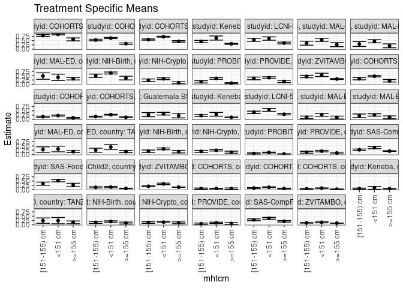

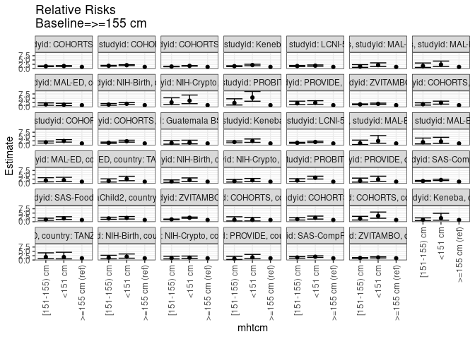

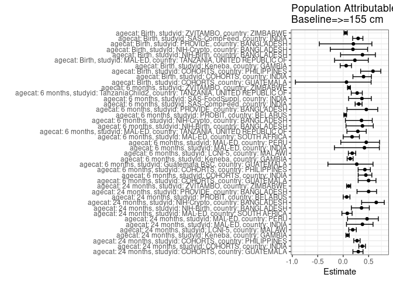

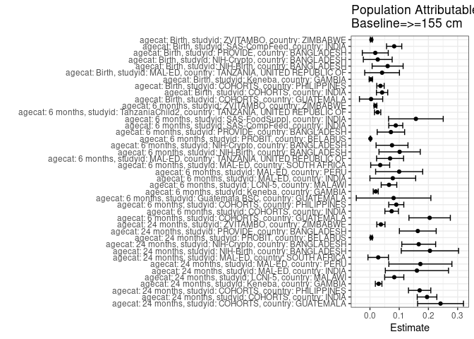

## Results Table

### Parameter: TSM

| agecat | studyid | country | intervention_level | baseline_level | estimate | ci_lower | ci_upper |
| --- | --- | --- | --- | --- | --- | --- | --- |
| Birth | COHORTS | GUATEMALA | >=155 cm | NA | 0.0545455 | 0.0120825 | 0.0970084 |
| Birth | COHORTS | GUATEMALA | <151 cm | NA | 0.0587156 | 0.0389666 | 0.0784646 |
| Birth | COHORTS | GUATEMALA | [151-155) cm | NA | 0.0594595 | 0.0253621 | 0.0935568 |
| Birth | COHORTS | INDIA | >=155 cm | NA | 0.0622642 | 0.0416867 | 0.0828416 |
| Birth | COHORTS | INDIA | <151 cm | NA | 0.1389253 | 0.1143771 | 0.1634735 |
| Birth | COHORTS | INDIA | [151-155) cm | NA | 0.0935551 | 0.0675234 | 0.1195868 |
| Birth | COHORTS | PHILIPPINES | >=155 cm | NA | 0.0253968 | 0.0131096 | 0.0376840 |
| Birth | COHORTS | PHILIPPINES | <151 cm | NA | 0.0854369 | 0.0714962 | 0.0993776 |
| Birth | COHORTS | PHILIPPINES | [151-155) cm | NA | 0.0445714 | 0.0308959 | 0.0582469 |
| Birth | Keneba | GAMBIA | >=155 cm | NA | 0.0480202 | 0.0358527 | 0.0601877 |
| Birth | Keneba | GAMBIA | <151 cm | NA | 0.0980392 | 0.0163982 | 0.1796803 |
| Birth | Keneba | GAMBIA | [151-155) cm | NA | 0.0569948 | 0.0242761 | 0.0897135 |
| Birth | MAL-ED | TANZANIA, UNITED REPUBLIC OF | >=155 cm | NA | 0.1388889 | 0.0586782 | 0.2190996 |
| Birth | MAL-ED | TANZANIA, UNITED REPUBLIC OF | <151 cm | NA | 0.2380952 | 0.0551794 | 0.4210111 |
| Birth | MAL-ED | TANZANIA, UNITED REPUBLIC OF | [151-155) cm | NA | 0.2413793 | 0.0849930 | 0.3977656 |
| Birth | NIH-Birth | BANGLADESH | >=155 cm | NA | 0.0990991 | 0.0434680 | 0.1547302 |
| Birth | NIH-Birth | BANGLADESH | <151 cm | NA | 0.1882022 | 0.1475657 | 0.2288388 |
| Birth | NIH-Birth | BANGLADESH | [151-155) cm | NA | 0.1347518 | 0.0783447 | 0.1911588 |
| Birth | NIH-Crypto | BANGLADESH | >=155 cm | NA | 0.1119403 | 0.0585198 | 0.1653608 |
| Birth | NIH-Crypto | BANGLADESH | <151 cm | NA | 0.1507177 | 0.1163962 | 0.1850392 |
| Birth | NIH-Crypto | BANGLADESH | [151-155) cm | NA | 0.1299435 | 0.0803745 | 0.1795125 |
| Birth | PROVIDE | BANGLADESH | >=155 cm | NA | 0.0727273 | 0.0241510 | 0.1213036 |
| Birth | PROVIDE | BANGLADESH | <151 cm | NA | 0.1118881 | 0.0753193 | 0.1484570 |
| Birth | PROVIDE | BANGLADESH | [151-155) cm | NA | 0.0578512 | 0.0162130 | 0.0994894 |
| Birth | SAS-CompFeed | INDIA | >=155 cm | NA | 0.1991435 | 0.1562605 | 0.2420265 |
| Birth | SAS-CompFeed | INDIA | <151 cm | NA | 0.3766234 | 0.3234789 | 0.4297679 |
| Birth | SAS-CompFeed | INDIA | [151-155) cm | NA | 0.2897527 | 0.2363607 | 0.3431446 |
| Birth | ZVITAMBO | ZIMBABWE | >=155 cm | NA | 0.0940248 | 0.0875190 | 0.1005307 |
| Birth | ZVITAMBO | ZIMBABWE | <151 cm | NA | 0.1392857 | 0.1106070 | 0.1679644 |
| Birth | ZVITAMBO | ZIMBABWE | [151-155) cm | NA | 0.1089880 | 0.0927388 | 0.1252371 |

[output cut: 93 more lines]

### Parameter: E(Y)

| agecat | studyid | country | intervention_level | baseline_level | estimate | ci_lower | ci_upper |
| --- | --- | --- | --- | --- | --- | --- | --- |
| Birth | COHORTS | GUATEMALA | NA | NA | 0.0583333 | 0.0424744 | 0.0741923 |
| Birth | COHORTS | INDIA | NA | NA | 0.1037204 | 0.0895283 | 0.1179125 |
| Birth | COHORTS | PHILIPPINES | NA | NA | 0.0613115 | 0.0527962 | 0.0698268 |
| Birth | Keneba | GAMBIA | NA | NA | 0.0510133 | 0.0396094 | 0.0624171 |
| Birth | MAL-ED | TANZANIA, UNITED REPUBLIC OF | NA | NA | 0.1803279 | 0.1118253 | 0.2488304 |
| Birth | NIH-Birth | BANGLADESH | NA | NA | 0.1595395 | 0.1304091 | 0.1886699 |
| Birth | NIH-Crypto | BANGLADESH | NA | NA | 0.1385460 | 0.1134505 | 0.1636414 |
| Birth | PROVIDE | BANGLADESH | NA | NA | 0.0909091 | 0.0661046 | 0.1157136 |
| Birth | SAS-CompFeed | INDIA | NA | NA | 0.2819383 | 0.2495848 | 0.3142918 |
| Birth | ZVITAMBO | ZIMBABWE | NA | NA | 0.0988150 | 0.0928777 | 0.1047524 |
| 6 months | COHORTS | GUATEMALA | NA | NA | 0.4093319 | 0.3779317 | 0.4407321 |
| 6 months | COHORTS | INDIA | NA | NA | 0.1665750 | 0.1494477 | 0.1837024 |
| 6 months | COHORTS | PHILIPPINES | NA | NA | 0.2112260 | 0.1958496 | 0.2266024 |
| 6 months | Guatemala BSC | GUATEMALA | NA | NA | 0.3030303 | 0.2436375 | 0.3624232 |
| 6 months | Keneba | GAMBIA | NA | NA | 0.1427810 | 0.1269499 | 0.1586122 |
| 6 months | LCNI-5 | MALAWI | NA | NA | 0.3672249 | 0.3345288 | 0.3999210 |
| 6 months | MAL-ED | INDIA | NA | NA | 0.1872340 | 0.1372518 | 0.2372162 |
| 6 months | MAL-ED | PERU | NA | NA | 0.2205882 | 0.1712211 | 0.2699554 |
| 6 months | MAL-ED | SOUTH AFRICA | NA | NA | 0.2008032 | 0.1509453 | 0.2506612 |
| 6 months | MAL-ED | TANZANIA, UNITED REPUBLIC OF | NA | NA | 0.2388664 | 0.1855834 | 0.2921494 |
| 6 months | NIH-Birth | BANGLADESH | NA | NA | 0.2681564 | 0.2306532 | 0.3056597 |
| 6 months | NIH-Crypto | BANGLADESH | NA | NA | 0.2097902 | 0.1799252 | 0.2396552 |
| 6 months | PROBIT | BELARUS | NA | NA | 0.0368352 | 0.0276810 | 0.0459895 |
| 6 months | PROVIDE | BANGLADESH | NA | NA | 0.1575456 | 0.1284434 | 0.1866478 |
| 6 months | SAS-CompFeed | INDIA | NA | NA | 0.2882736 | 0.2624662 | 0.3140810 |
| 6 months | SAS-FoodSuppl | INDIA | NA | NA | 0.4274406 | 0.3775694 | 0.4773119 |
| 6 months | TanzaniaChild2 | TANZANIA, UNITED REPUBLIC OF | NA | NA | 0.0951904 | 0.0823123 | 0.1080685 |
| 6 months | ZVITAMBO | ZIMBABWE | NA | NA | 0.1632405 | 0.1548158 | 0.1716651 |
| 24 months | COHORTS | GUATEMALA | NA | NA | 0.8128773 | 0.7886196 | 0.8371349 |
| 24 months | COHORTS | INDIA | NA | NA | 0.5195162 | 0.4965500 | 0.5424825 |
| 24 months | COHORTS | PHILIPPINES | NA | NA | 0.6229039 | 0.6036892 | 0.6421186 |
| 24 months | Keneba | GAMBIA | NA | NA | 0.3420724 | 0.3188343 | 0.3653105 |
| 24 months | LCNI-5 | MALAWI | NA | NA | 0.4436742 | 0.4031015 | 0.4842468 |
| 24 months | MAL-ED | INDIA | NA | NA | 0.4247788 | 0.3601902 | 0.4893673 |
| 24 months | MAL-ED | PERU | NA | NA | 0.3681592 | 0.3013164 | 0.4350020 |
| 24 months | MAL-ED | SOUTH AFRICA | NA | NA | 0.3504274 | 0.2891665 | 0.4116882 |
| 24 months | NIH-Birth | BANGLADESH | NA | NA | 0.5687646 | 0.5218455 | 0.6156837 |
| 24 months | NIH-Crypto | BANGLADESH | NA | NA | 0.2568093 | 0.2190047 | 0.2946140 |
| 24 months | PROBIT | BELARUS | NA | NA | 0.0679151 | 0.0407521 | 0.0950781 |
| 24 months | PROVIDE | BANGLADESH | NA | NA | 0.3275563 | 0.2892291 | 0.3658836 |
| 24 months | ZVITAMBO | ZIMBABWE | NA | NA | 0.3464338 | 0.3212647 | 0.3716029 |

### Parameter: RR

| agecat | studyid | country | intervention_level | baseline_level | estimate | ci_lower | ci_upper |
| --- | --- | --- | --- | --- | --- | --- | --- |
| Birth | COHORTS | GUATEMALA | >=155 cm | >=155 cm | 1.0000000 | 1.0000000 | 1.000000 |
| Birth | COHORTS | GUATEMALA | <151 cm | >=155 cm | 1.0764526 | 0.4609940 | 2.513591 |
| Birth | COHORTS | GUATEMALA | [151-155) cm | >=155 cm | 1.0900901 | 0.4145183 | 2.866692 |
| Birth | COHORTS | INDIA | >=155 cm | >=155 cm | 1.0000000 | 1.0000000 | 1.000000 |
| Birth | COHORTS | INDIA | <151 cm | >=155 cm | 2.2312244 | 1.5338659 | 3.245631 |
| Birth | COHORTS | INDIA | [151-155) cm | >=155 cm | 1.5025515 | 0.9754475 | 2.314487 |
| Birth | COHORTS | PHILIPPINES | >=155 cm | >=155 cm | 1.0000000 | 1.0000000 | 1.000000 |
| Birth | COHORTS | PHILIPPINES | <151 cm | >=155 cm | 3.3640777 | 2.0189370 | 5.605434 |
| Birth | COHORTS | PHILIPPINES | [151-155) cm | >=155 cm | 1.7550000 | 0.9896269 | 3.112309 |
| Birth | Keneba | GAMBIA | >=155 cm | >=155 cm | 1.0000000 | 1.0000000 | 1.000000 |
| Birth | Keneba | GAMBIA | <151 cm | >=155 cm | 2.0416237 | 0.8549698 | 4.875292 |
| Birth | Keneba | GAMBIA | [151-155) cm | >=155 cm | 1.1868921 | 0.6337132 | 2.222950 |
| Birth | MAL-ED | TANZANIA, UNITED REPUBLIC OF | >=155 cm | >=155 cm | 1.0000000 | 1.0000000 | 1.000000 |
| Birth | MAL-ED | TANZANIA, UNITED REPUBLIC OF | <151 cm | >=155 cm | 1.7142857 | 0.6556608 | 4.482158 |
| Birth | MAL-ED | TANZANIA, UNITED REPUBLIC OF | [151-155) cm | >=155 cm | 1.7379310 | 0.7296261 | 4.139661 |
| Birth | NIH-Birth | BANGLADESH | >=155 cm | >=155 cm | 1.0000000 | 1.0000000 | 1.000000 |
| Birth | NIH-Birth | BANGLADESH | <151 cm | >=155 cm | 1.8991318 | 1.0407439 | 3.465503 |
| Birth | NIH-Birth | BANGLADESH | [151-155) cm | >=155 cm | 1.3597679 | 0.6750672 | 2.738940 |
| Birth | NIH-Crypto | BANGLADESH | >=155 cm | >=155 cm | 1.0000000 | 1.0000000 | 1.000000 |
| Birth | NIH-Crypto | BANGLADESH | <151 cm | >=155 cm | 1.3464115 | 0.7934792 | 2.284652 |
| Birth | NIH-Crypto | BANGLADESH | [151-155) cm | >=155 cm | 1.1608286 | 0.6301391 | 2.138453 |
| Birth | PROVIDE | BANGLADESH | >=155 cm | >=155 cm | 1.0000000 | 1.0000000 | 1.000000 |
| Birth | PROVIDE | BANGLADESH | <151 cm | >=155 cm | 1.5384615 | 0.7313825 | 3.236151 |
| Birth | PROVIDE | BANGLADESH | [151-155) cm | >=155 cm | 0.7954545 | 0.2979717 | 2.123517 |
| Birth | SAS-CompFeed | INDIA | >=155 cm | >=155 cm | 1.0000000 | 1.0000000 | 1.000000 |
| Birth | SAS-CompFeed | INDIA | <151 cm | >=155 cm | 1.8912163 | 1.4943928 | 2.393413 |
| Birth | SAS-CompFeed | INDIA | [151-155) cm | >=155 cm | 1.4549945 | 1.0671418 | 1.983812 |
| Birth | ZVITAMBO | ZIMBABWE | >=155 cm | >=155 cm | 1.0000000 | 1.0000000 | 1.000000 |
| Birth | ZVITAMBO | ZIMBABWE | <151 cm | >=155 cm | 1.4813716 | 1.1921457 | 1.840766 |
| Birth | ZVITAMBO | ZIMBABWE | [151-155) cm | >=155 cm | 1.1591403 | 0.9834521 | 1.366214 |

[output cut: 93 more lines]

### Parameter: PAR

| agecat | studyid | country | intervention_level | baseline_level | estimate | ci_lower | ci_upper |
| --- | --- | --- | --- | --- | --- | --- | --- |
| Birth | COHORTS | GUATEMALA | >=155 cm | NA | 0.0037879 | -0.0359911 | 0.0435668 |
| Birth | COHORTS | INDIA | >=155 cm | NA | 0.0414563 | 0.0221731 | 0.0607394 |
| Birth | COHORTS | PHILIPPINES | >=155 cm | NA | 0.0359147 | 0.0232215 | 0.0486078 |
| Birth | Keneba | GAMBIA | >=155 cm | NA | 0.0029931 | -0.0027067 | 0.0086929 |
| Birth | MAL-ED | TANZANIA, UNITED REPUBLIC OF | >=155 cm | NA | 0.0414390 | -0.0179952 | 0.1008731 |
| Birth | NIH-Birth | BANGLADESH | >=155 cm | NA | 0.0604404 | 0.0073991 | 0.1134817 |
| Birth | NIH-Crypto | BANGLADESH | >=155 cm | NA | 0.0266057 | -0.0227342 | 0.0759455 |
| Birth | PROVIDE | BANGLADESH | >=155 cm | NA | 0.0181818 | -0.0262120 | 0.0625756 |
| Birth | SAS-CompFeed | INDIA | >=155 cm | NA | 0.0827949 | 0.0567801 | 0.1088096 |
| Birth | ZVITAMBO | ZIMBABWE | >=155 cm | NA | 0.0047902 | 0.0016066 | 0.0079738 |
| 6 months | COHORTS | GUATEMALA | >=155 cm | NA | 0.2042037 | 0.1333852 | 0.2750222 |
| 6 months | COHORTS | INDIA | >=155 cm | NA | 0.0741536 | 0.0510279 | 0.0972793 |
| 6 months | COHORTS | PHILIPPINES | >=155 cm | NA | 0.0900139 | 0.0642500 | 0.1157778 |
| 6 months | Guatemala BSC | GUATEMALA | >=155 cm | NA | 0.0808081 | -0.0467748 | 0.2083909 |
| 6 months | Keneba | GAMBIA | >=155 cm | NA | 0.0196943 | 0.0111409 | 0.0282477 |
| 6 months | LCNI-5 | MALAWI | >=155 cm | NA | 0.0650806 | 0.0384393 | 0.0917219 |
| 6 months | MAL-ED | INDIA | >=155 cm | NA | 0.0781431 | -0.0001154 | 0.1564017 |
| 6 months | MAL-ED | PERU | >=155 cm | NA | 0.0998986 | 0.0193802 | 0.1804169 |
| 6 months | MAL-ED | SOUTH AFRICA | >=155 cm | NA | 0.0350278 | 0.0025639 | 0.0674917 |
| 6 months | MAL-ED | TANZANIA, UNITED REPUBLIC OF | >=155 cm | NA | 0.0687984 | 0.0225991 | 0.1149976 |
| 6 months | NIH-Birth | BANGLADESH | >=155 cm | NA | 0.1014898 | 0.0308943 | 0.1720852 |
| 6 months | NIH-Crypto | BANGLADESH | >=155 cm | NA | 0.0754619 | 0.0208824 | 0.1300413 |
| 6 months | PROBIT | BELARUS | >=155 cm | NA | 0.0014829 | 0.0004075 | 0.0025583 |
| 6 months | PROVIDE | BANGLADESH | >=155 cm | NA | 0.0716081 | 0.0246421 | 0.1185741 |
| 6 months | SAS-CompFeed | INDIA | >=155 cm | NA | 0.0882736 | 0.0642729 | 0.1122743 |
| 6 months | SAS-FoodSuppl | INDIA | >=155 cm | NA | 0.1571704 | 0.0636619 | 0.2506789 |
| 6 months | TanzaniaChild2 | TANZANIA, UNITED REPUBLIC OF | >=155 cm | NA | 0.0261695 | 0.0153717 | 0.0369673 |
| 6 months | ZVITAMBO | ZIMBABWE | >=155 cm | NA | 0.0187092 | 0.0138965 | 0.0235219 |
| 24 months | COHORTS | GUATEMALA | >=155 cm | NA | 0.2414487 | 0.1629149 | 0.3199825 |
| 24 months | COHORTS | INDIA | >=155 cm | NA | 0.1952409 | 0.1616674 | 0.2288143 |
| 24 months | COHORTS | PHILIPPINES | >=155 cm | NA | 0.1699627 | 0.1317865 | 0.2081389 |
| 24 months | Keneba | GAMBIA | >=155 cm | NA | 0.0296658 | 0.0184279 | 0.0409037 |
| 24 months | LCNI-5 | MALAWI | >=155 cm | NA | 0.0831108 | 0.0503989 | 0.1158227 |
| 24 months | MAL-ED | INDIA | >=155 cm | NA | 0.1606278 | 0.0525284 | 0.2687273 |
| 24 months | MAL-ED | PERU | >=155 cm | NA | 0.1725070 | 0.0646625 | 0.2803516 |
| 24 months | MAL-ED | SOUTH AFRICA | >=155 cm | NA | 0.0282051 | -0.0069008 | 0.0633110 |
| 24 months | NIH-Birth | BANGLADESH | >=155 cm | NA | 0.2051282 | 0.1070514 | 0.3032050 |
| 24 months | NIH-Crypto | BANGLADESH | >=155 cm | NA | 0.1668093 | 0.1088878 | 0.2247309 |
| 24 months | PROBIT | BELARUS | >=155 cm | NA | 0.0046863 | 0.0012770 | 0.0080956 |
| 24 months | PROVIDE | BANGLADESH | >=155 cm | NA | 0.1636219 | 0.1006618 | 0.2265819 |
| 24 months | ZVITAMBO | ZIMBABWE | >=155 cm | NA | 0.0373932 | 0.0233976 | 0.0513888 |

### Parameter: PAF

| agecat | studyid | country | intervention_level | baseline_level | estimate | ci_lower | ci_upper |
| --- | --- | --- | --- | --- | --- | --- | --- |
| Birth | COHORTS | GUATEMALA | >=155 cm | NA | 0.0649351 | -0.9385216 | 0.5489623 |
| Birth | COHORTS | INDIA | >=155 cm | NA | 0.3996924 | 0.1913390 | 0.5543630 |
| Birth | COHORTS | PHILIPPINES | >=155 cm | NA | 0.5857737 | 0.3426202 | 0.7389889 |
| Birth | Keneba | GAMBIA | >=155 cm | NA | 0.0586721 | -0.0591796 | 0.1634109 |
| Birth | MAL-ED | TANZANIA, UNITED REPUBLIC OF | >=155 cm | NA | 0.2297980 | -0.1697411 | 0.4928697 |
| Birth | NIH-Birth | BANGLADESH | >=155 cm | NA | 0.3788428 | -0.0514147 | 0.6330313 |
| Birth | NIH-Crypto | BANGLADESH | >=155 cm | NA | 0.1920349 | -0.2535429 | 0.4792299 |
| Birth | PROVIDE | BANGLADESH | >=155 cm | NA | 0.2000000 | -0.4682360 | 0.5641028 |
| Birth | SAS-CompFeed | INDIA | >=155 cm | NA | 0.2936630 | 0.1858008 | 0.3872360 |
| Birth | ZVITAMBO | ZIMBABWE | >=155 cm | NA | 0.0484765 | 0.0158150 | 0.0800542 |
| 6 months | COHORTS | GUATEMALA | >=155 cm | NA | 0.4988707 | 0.2940709 | 0.6442553 |
| 6 months | COHORTS | INDIA | >=155 cm | NA | 0.4451663 | 0.2950895 | 0.5632915 |
| 6 months | COHORTS | PHILIPPINES | >=155 cm | NA | 0.4261496 | 0.2936545 | 0.5337915 |
| 6 months | Guatemala BSC | GUATEMALA | >=155 cm | NA | 0.2666667 | -0.2999982 | 0.5863242 |
| 6 months | Keneba | GAMBIA | >=155 cm | NA | 0.1379336 | 0.0774052 | 0.1944909 |
| 6 months | LCNI-5 | MALAWI | >=155 cm | NA | 0.1772228 | 0.1014651 | 0.2465933 |
| 6 months | MAL-ED | INDIA | >=155 cm | NA | 0.4173554 | -0.1715170 | 0.7102263 |
| 6 months | MAL-ED | PERU | >=155 cm | NA | 0.4528736 | -0.0471592 | 0.7141339 |
| 6 months | MAL-ED | SOUTH AFRICA | >=155 cm | NA | 0.1744385 | 0.0000171 | 0.3184365 |
| 6 months | MAL-ED | TANZANIA, UNITED REPUBLIC OF | >=155 cm | NA | 0.2880203 | 0.0736236 | 0.4527979 |
| 6 months | NIH-Birth | BANGLADESH | >=155 cm | NA | 0.3784722 | 0.0551128 | 0.5911716 |
| 6 months | NIH-Crypto | BANGLADESH | >=155 cm | NA | 0.3597015 | 0.0437494 | 0.5712607 |
| 6 months | PROBIT | BELARUS | >=155 cm | NA | 0.0402580 | 0.0137905 | 0.0660151 |
| 6 months | PROVIDE | BANGLADESH | >=155 cm | NA | 0.4545230 | 0.0742169 | 0.6786017 |
| 6 months | SAS-CompFeed | INDIA | >=155 cm | NA | 0.3062147 | 0.2345096 | 0.3712030 |
| 6 months | SAS-FoodSuppl | INDIA | >=155 cm | NA | 0.3677010 | 0.1066562 | 0.5524657 |
| 6 months | TanzaniaChild2 | TANZANIA, UNITED REPUBLIC OF | >=155 cm | NA | 0.2749176 | 0.1582939 | 0.3753824 |
| 6 months | ZVITAMBO | ZIMBABWE | >=155 cm | NA | 0.1146114 | 0.0850371 | 0.1432298 |
| 24 months | COHORTS | GUATEMALA | >=155 cm | NA | 0.2970297 | 0.1911027 | 0.3890853 |
| 24 months | COHORTS | INDIA | >=155 cm | NA | 0.3758128 | 0.3069003 | 0.4378736 |
| 24 months | COHORTS | PHILIPPINES | >=155 cm | NA | 0.2728554 | 0.2080346 | 0.3323708 |
| 24 months | Keneba | GAMBIA | >=155 cm | NA | 0.0867238 | 0.0533010 | 0.1189667 |
| 24 months | LCNI-5 | MALAWI | >=155 cm | NA | 0.1873239 | 0.1095032 | 0.2583439 |
| 24 months | MAL-ED | INDIA | >=155 cm | NA | 0.3781447 | 0.0644934 | 0.5866367 |
| 24 months | MAL-ED | PERU | >=155 cm | NA | 0.4685664 | 0.0859712 | 0.6910145 |
| 24 months | MAL-ED | SOUTH AFRICA | >=155 cm | NA | 0.0804878 | -0.0253447 | 0.1753967 |
| 24 months | NIH-Birth | BANGLADESH | >=155 cm | NA | 0.3606557 | 0.1604246 | 0.5131335 |
| 24 months | NIH-Crypto | BANGLADESH | >=155 cm | NA | 0.6495455 | 0.3626160 | 0.8073086 |
| 24 months | PROBIT | BELARUS | >=155 cm | NA | 0.0690022 | 0.0004644 | 0.1328404 |
| 24 months | PROVIDE | BANGLADESH | >=155 cm | NA | 0.4995229 | 0.2719216 | 0.6559748 |
| 24 months | ZVITAMBO | ZIMBABWE | >=155 cm | NA | 0.1079375 | 0.0666530 | 0.1473958 |